# Reproducible Research Course Project 1

## Loading and preprocessing the data

Downdload raw file from [Activity Monitoring data](https://d396qusza40orc.cloudfront.net/repdata%2Fdata%2Factivity.zip) and unzip it.

Code for reading in the dataset and/or processing the data  
1.Load the data file

```r
df <- read.csv("./repdata_data_activity/activity.csv",na.string = NA)
```

2.Process the data - changing date to POSIXct for later computation

```r
df$date <- as.POSIXct(strptime(df$date, format = "%Y-%m-%d"))
str(df)
```

```
## 'data.frame':    17568 obs. of  3 variables:
##  $ steps   : int  NA NA NA NA NA NA NA NA NA NA ...
##  $ date    : POSIXct, format: "2012-10-01" "2012-10-01" ...
##  $ interval: int  0 5 10 15 20 25 30 35 40 45 ...
```

## What is mean total number of steps taken per day?

Approach: Ignore the missing values in the dataset.

1.Calculate the total number of steps taken per day

```r
Sum <- aggregate(steps~date,data=df, sum, na.rm=TRUE)
str(Sum)
```

```
## 'data.frame':    53 obs. of  2 variables:
##  $ date : POSIXct, format: "2012-10-02" "2012-10-03" ...
##  $ steps: int  126 11352 12116 13294 15420 11015 12811 9900 10304 17382 ...
```

2.Plot on histgram

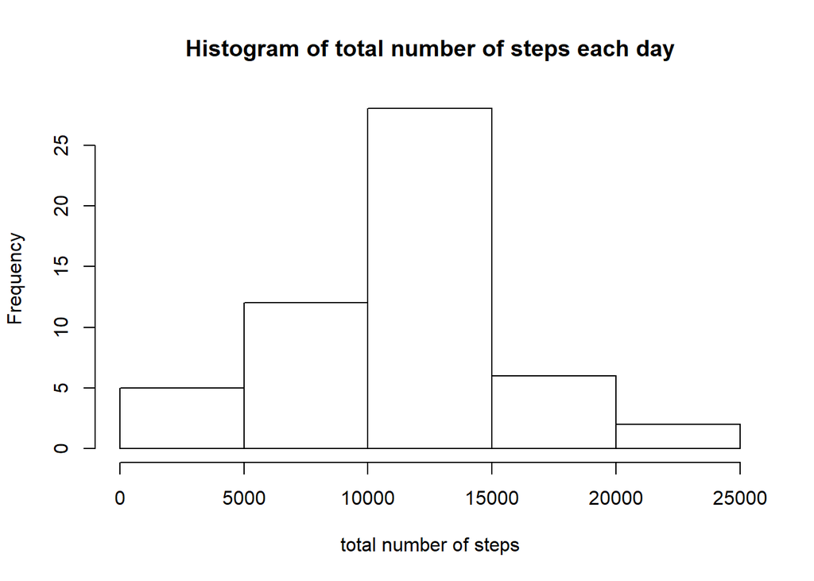

```r
hist(Sum$steps, main = "Histogram of total number of steps each day"
              , xlab = "total number of steps")
```

3.Mean and median number of steps taken each day

```r
# mean
mean(Sum$steps,na.rm=TRUE)
```

```
## [1] 10766.19
```

```r
# median
median(Sum$steps, na.rm=TRUE)
```

```
## [1] 10765
```

Note that mean and median are slightly different.

## What is the average daily activity pattern?

1.Make a time series plot (i.e. type=“l”) of the 5-minute interval (x-axis) and the average number of steps taken, averaged across all days (y-axis)

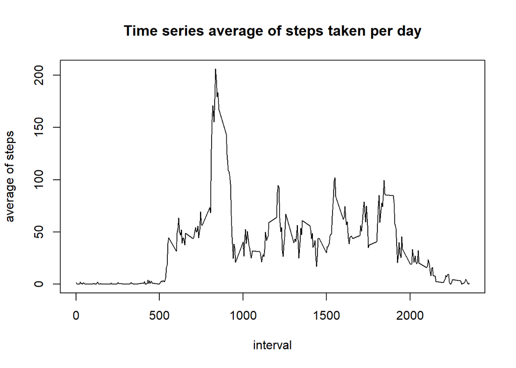

```r
# Calculate the average of steps taken per day
Ave <- aggregate(steps~interval,data=df, mean, na.rm=TRUE)
# plot with the line
plot(Ave,main = "Time series average of steps taken per day"
                ,xlab="interval"
                ,ylab="average of steps"
                ,type="l")
```

2.Which 5-minute interval, on average across all the days in the dataset, contains the maximum number of steps?

```r
Ave[which.max(Ave$steps),]
```

```
##     interval    steps
## 104      835 206.1698
```

## Imputing missing values

Note that there are a number of days/intervals where there are missing values (coded as NA). The presence of missing days may introduce bias into some calculations or summaries of the data.

1.Calculate and report the total number of missing values in the dataset (i.e. the total number of rows with NAs)

```r
# indicate number of NAs for each column in the data set.
colSums(is.na(df))
```

```
##    steps     date interval
##     2304        0        0
```

So the answer is 2304

2.Devise a strategy for filling in all of the missing values in the dataset.  
The strategy does not need to be sophisticated. For example, you could use the mean/median for that day, or the mean for that 5-minute interval, etc.

The strategy I take here is **mean imputation**.

Investigate the pattern of NAs

```r
# count rows including NA per date
NAdate <- table(df[!complete.cases(df),"date"])
NAdate
```

```
##
## 2012-10-01 2012-10-08 2012-11-01 2012-11-04 2012-11-09 2012-11-10 2012-11-14
##        288        288        288        288        288        288        288
## 2012-11-30
##        288
```

Now let’s see the impact by missing value comparing with the date above.

```r
head(Sum,10)
```

```
##          date steps
## 1  2012-10-02   126
## 2  2012-10-03 11352
## 3  2012-10-04 12116
## 4  2012-10-05 13294
## 5  2012-10-06 15420
## 6  2012-10-07 11015
## 7  2012-10-09 12811
## 8  2012-10-10  9900
## 9  2012-10-11 10304
## 10 2012-10-12 17382
```

Actually 2012-10-01 and 2012-10-08 were not listed in top 10 rows of data frame ‘Sum’.  
It is result of bais introduced by missing value and reason is that aggregate function ignored the rows which includes NA.

3.Create a new dataset that is equal to the original dataset but with the missing data filled in.

```r
# making imputed data set
imputed_temp <- data.frame()  # prepare initial empty dataframe
for (i in 1:length(names(NAdate))){
  # extract the date having NA one by one
  temp <- subset(df,df$date == names(NAdate[i]))
  # merge average data with the key = interval.
  temp<- merge(temp,Ave,by = "interval")
  temp <- temp[,c(4,3,1)]    # change order of columns
  colnames(temp)[1] <- "steps"
  imputed_temp <- rbind(imputed_temp,temp)  # append to imputed data set
}
  imputed_df <- subset(df,!df$date %in% names(NAdate)) # exclude NA dates
  imputed_df <- rbind(imputed_df,imputed_temp)      # append imputed dates
  imputed_df <- imputed_df[order(imputed_df$date),] # sort by date
  colSums(is.na(imputed_df))  # check if any NA found
```

[output not shown]

4.Make a histogram of the total number of steps taken each day and Calculate and report the mean and median total number of steps taken per day.

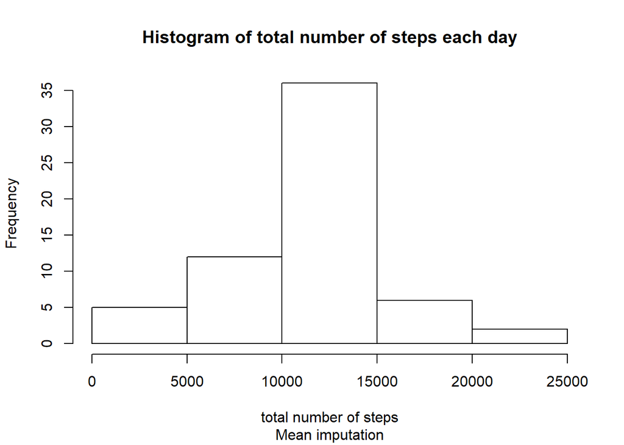

```r
# compute total number of steps each day on imputed data set
imputedSum <- aggregate(steps~date,data=imputed_df, sum, na.rm=TRUE)
# plot
hist(imputedSum$steps, main = "Histogram of total number of steps each day"
              , sub = "Mean imputation"
              , xlab = "total number of steps")
```

Do these values differ from the estimates from the first part of the assignment?  
What is the impact of imputing missing data on the estimates of the total daily number of steps?

```r
# mean
mean(imputedSum$steps,na.rm=TRUE)
```

```
## [1] 10766.19
```

```r
# median
median(imputedSum$steps, na.rm=TRUE)
```

```
## [1] 10766.19
```

**Result of imputation**  
- After applying mean impuation, frequency at the centor bin of histgram is increased.  
- Now mean and median are same value.

## Are there differences in activity patterns between weekdays and weekends?

For this part the weekdays() function may be of some help here. Use the dataset with the filled-in missing values for this part.  
1.Create a new factor variable in the dataset with two levels – “weekday” and “weekend” indicating whether a given date is a weekday or weekend day.

```r
# add new columns named daytype tags "weekday" or "weekend"
imputed_df$daytype <- ifelse(weekdays(as.Date(imputed_df$date)) %in%
         c("Saturday", "Sunday"), "weekend", "weekday")
# change to factor
imputed_df$daytype <- as.factor(imputed_df$daytype)

# Calculate the average of steps taken per day on the imputed data
imputedAve <- aggregate(steps~interval+daytype,data=imputed_df,mean,na.rm=TRUE)
```

2.Make a panel plot containing a time series plot (i.e. type = “l”) of the 5-minute interval (x-axis) and the average number of steps taken, averaged across all weekday days or weekend days (y-axis).

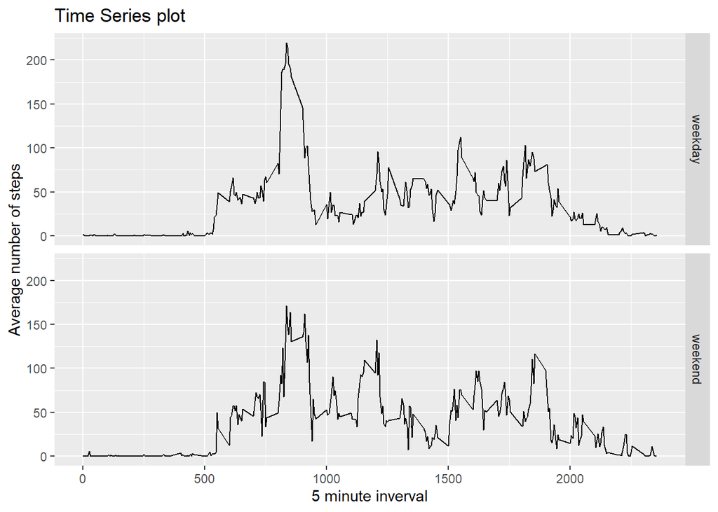

```r
library(ggplot2)
ggplot(imputedAve, aes(interval, steps)) +
  geom_line() +
  facet_grid(daytype ~ .) +
  xlab("5 minute inverval") +
  ylab("Average number of steps") +
  ggtitle("Time Series plot")
```